# Lab11

zewahyu

### How Often Did Trump Mention His Competitors in the 2016 Presidential Campaign?

We are going to reproduce the graph shown in expected result. In order to reproduce this graph, we need to analyse the text of Trump’s tweets to identify candidates having been mentioned. A candidate is considered having been mentioned if her/his last name, first name, full name appeared in the tweet. We restrict our analysis to the following candidates: Jeb Bush, Hillary Clinton, Ted Cruz, and Marco Rubio, and to the period from Oct. 1st, 2015 to Jul. 30th, 2016.

Use appropriate string operations in `stringr` together with **regular expressions** to analyze the text of tweets.

- `Tweet`: ids of a tweet;
- `Date`: the date the message got tweeted;
- `Candidate`: the candidate’s capitalised last name if s/he was mentioned in the tweet. (`toupper()` can be used).

After getting the Count for each candidate on each day, you need to add a `complete()` in order to fill zero count to those days that Trump did not mention the candidate, and `bind_rows()` to add the “starting” and “ending” points of the graph to zero.

```r
%>% complete(Date = seq(ymd("2015-10-1"), ymd("2016-7-30"), by = "day"), Candidate, fill = list(Count = 0)) %>%
  bind_rows(tibble(Date = ymd("2016-8-1"), Candidate = c("CRUZ", "BUSH", "CLINTON", "RUBIO"), Count = 0)) %>%
  bind_rows(tibble(Date = ymd("2015-9-29"), Candidate = c("CRUZ", "BUSH", "CLINTON", "RUBIO"), Count = 0)) %>%
```

TASK1: hint: using str_extract

After adding the complete code, the result will be the below.

```
## # A tibble: 1,224 x 3
##    Date       Candidate Count
##    <date>     <chr>     <dbl>
##  1 2015-09-29 BUSH          0
##  2 2015-09-29 CLINTON       0
##  3 2015-09-29 CRUZ          0
##  4 2015-09-29 RUBIO         0
##  5 2015-10-01 BUSH          0
##  6 2015-10-01 CLINTON       0
##  7 2015-10-01 CRUZ          3
##  8 2015-10-01 RUBIO         0
##  9 2015-10-02 BUSH          4
## 10 2015-10-02 CLINTON       0
## # ... with 1,214 more rows
```

TASK2:

[output not shown]

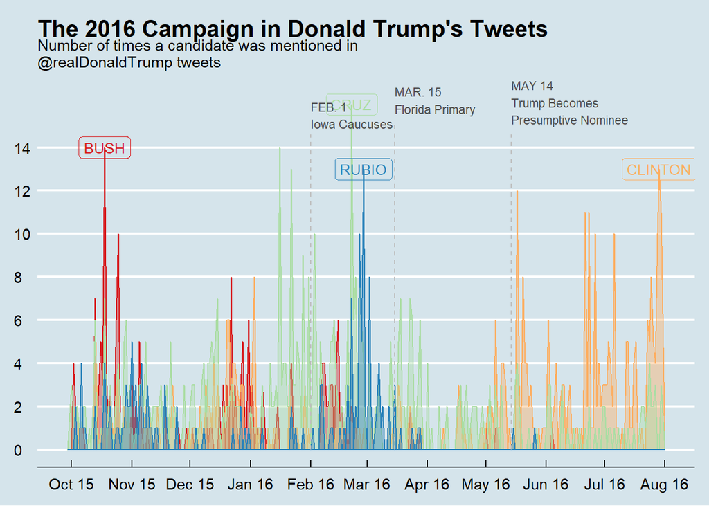